# Instagram Advertisement Survey - which types of advertisements are more likely to attract users to click on them

## What made people click?

The bar chart indicates that the longer people watch an advertisement, the more likely they are to click on it. Among those who clicked, internal influences such as music or engaging video appear to be more effective in attracting attention than external factors like influencers or discounts (6 seconds vs 4 seconds). This suggests that the design and content of the video itself play a key role in capturing user interest.

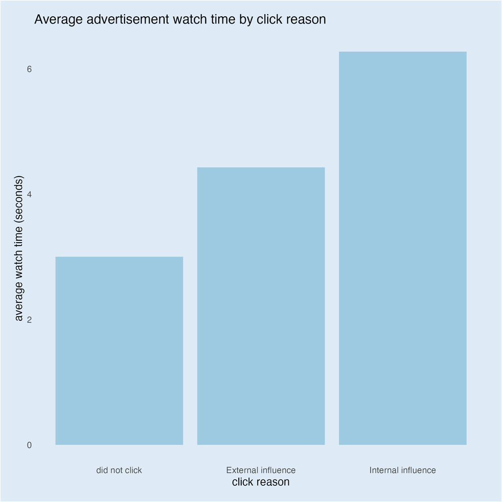

Average advertisement watch time by click reason

## When were people more likely to watch advertisements?

This research was done to determine whether the day affects how long people watch advertisements. The results show that there is no significant difference between Tuesday and Saturday, although people tend to watch slightly longer on Tuesday (as seen in the larger number of data points above 5 seconds). This suggests that the day of the week does not strongly affect watching time. However, since there is a small difference between weekdays (Tuesday) and weekends (Saturday), showing advertisements on weekdays may be more effective in attracting people’s interest. This may be because people tend to use Instagram more frequently during weekdays, such as while commuting to work.

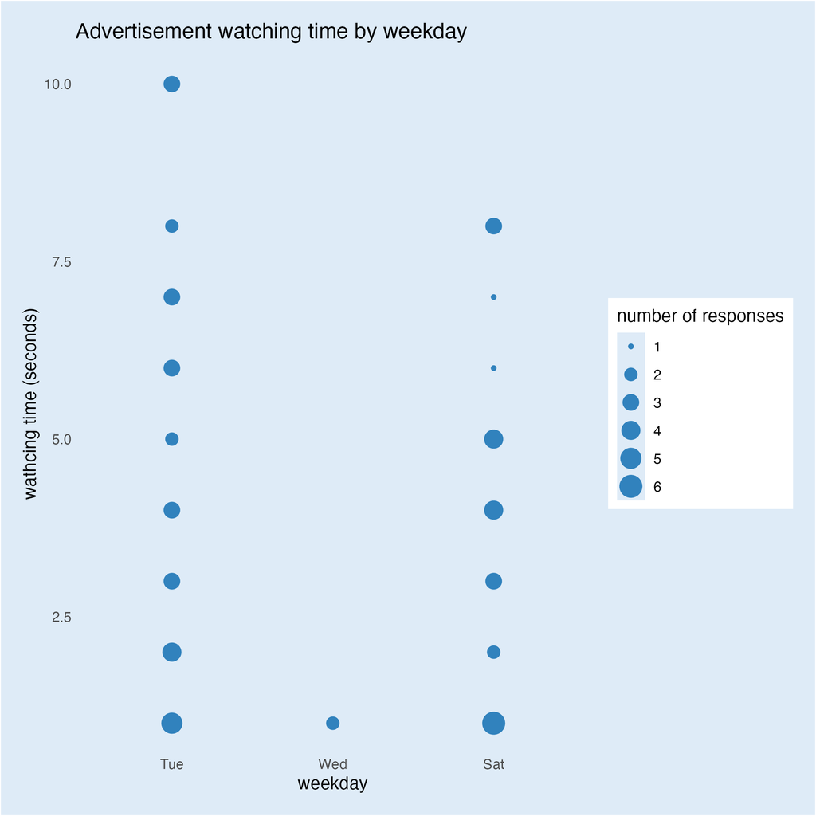

Advertisement watching time by weekday

## Did interest relate to clicking?

This plot shows a clear difference in interest levels between those who clicked and those who did not, as there is no overlap between the two boxplots. This suggests that the more interesting people find an advertisement, the more likely they are to click on it. Therefore, making advertisements engaging is a key factor in encouraging user clicking. This can be done by focusing on internal factors or by presenting advertisements on weekdays, as suggested by the previous plots.

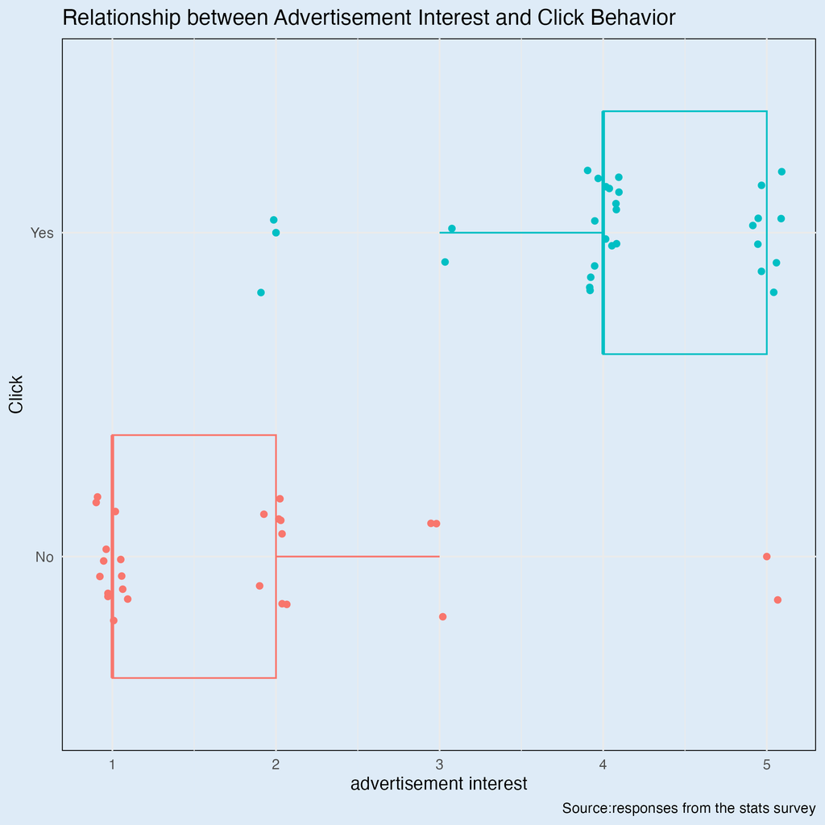

Relationship between Advertisement Interest and Click Behavior